# An Examination of the 2016 Presidential Election

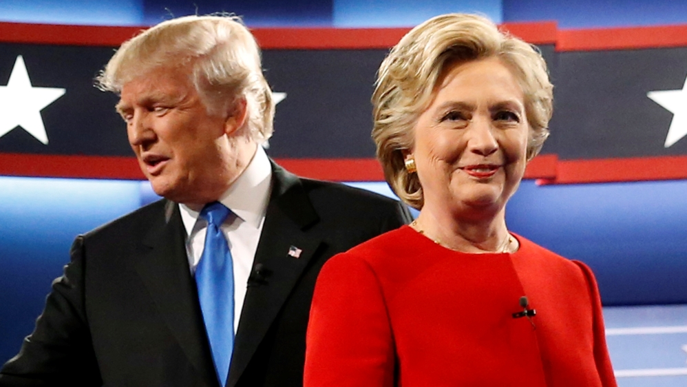

# 1. Introduction

The goal of the project is to closely examine the voting behaviors towards 2016 presidential election. By analyzing the data, we want to address questions like:

- Does the survey result about who they voted agree on the actual election result?
- Are there any demographic differences between the coalitions that support the two major party nominees?
- Is this the case that people don’t care about politics tend not to vote?

**Dataset**: The *American National Election Studies* (ANES) are surveys of voters in the U.S. on the national scale. For each presidential election since 1948, ANES collects responses from respondents both before and after the election. In this project, I only use some of the features in the *Time Series Cumulative Data* of ANES for 2016.

Below is the peek of the data we are going to use in this project.

```r
anes_use <- anes_data %>%
  mutate(
    year=as_factor(VCF0004),
    race=as_factor(VCF0105b),
    gender=as_factor(VCF0104),
    age=as_factor(VCF0102),
    education=as_factor(VCF0110),
    class=as_factor(VCF0148a),
    votefor=as_factor(VCF0704),
    turnout=as_factor(VCF0702),
    interest=as_factor(VCF0310),
    discussion=as_factor(VCF0733),
    donation=as_factor(VCF0741)
  ) %>%
  filter(year == 2016)
```

```r
data.table(anes_use %>%
             select(turnout,votefor,
                    race,gender,age,education,class,
                    interest,discussion,donation)) %>%
  filter(!is.na(turnout)) %>%
  sample_n(10)
```

| turnout | votefor | race | gender | age | education | class | interest | discussion | donation |
| --- | --- | --- | --- | --- | --- | --- | --- | --- | --- |
| 2. Yes, voted | 2. Republican | 1. White non-Hispanic | 1. Male | 5. 55 - 64 | 3. Some college (13 grades or more but no degree; | 1. Average working | 3. Very much interested | 7. Every day | 2. No |
| 2. Yes, voted | NA | 1. White non-Hispanic | 1. Male | 7. 75 - 99 and over (except 1954) | 2. High school (12 grades or fewer, incl. non-college | 4. Average middle | 2. Somewhat interested | 1. One day | 2. No |
| 2. Yes, voted | 2. Republican | 1. White non-Hispanic | 1. Male | 2. 25 - 34 | 3. Some college (13 grades or more but no degree; | 4. Average middle | 2. Somewhat interested | 6. Six days | 2. No |
| 2. Yes, voted | 2. Republican | 1. White non-Hispanic | 1. Male | 4. 45 - 54 | 4. College or advanced degree (no cases 1948) | 1. Average working | 3. Very much interested | 7. Every day | 2. No |
| 2. Yes, voted | NA | 1. White non-Hispanic | 1. Male | 4. 45 - 54 | 3. Some college (13 grades or more but no degree; | 4. Average middle | 1. Not much interested | 2. Two days | 2. No |
| 2. Yes, voted | NA | 1. White non-Hispanic | 2. Female | 4. 45 - 54 | 3. Some college (13 grades or more but no degree; | 4. Average middle | 1. Not much interested | 2. Two days | 2. No |
| 2. Yes, voted | 2. Republican | 1. White non-Hispanic | 2. Female | 5. 55 - 64 | 3. Some college (13 grades or more but no degree; | 1. Average working | 3. Very much interested | 4. Four days | 2. No |
| 2. Yes, voted | 2. Republican | 1. White non-Hispanic | 2. Female | 3. 35 - 44 | 3. Some college (13 grades or more but no degree; | NA | 2. Somewhat interested | 1. One day | 2. No |
| 2. Yes, voted | 2. Republican | 4. Other or multiple races, non-Hispanic | 1. Male | 6. 65 - 74 | 4. College or advanced degree (no cases 1948) | 1. Average working | 3. Very much interested | NA | 2. No |
| 1. No, did not vote | NA | 1. White non-Hispanic | 2. Female | 2. 25 - 34 | 2. High school (12 grades or fewer, incl. non-college | 1. Average working | 2. Somewhat interested | NA | 2. No |

# 2. Data Analysis

## (i) General Statistics

[figure not shown]

[figure not shown]

In our sample, there are 79% people chose to vote for the president in 2016, while only 21% chose not to vote. Among these people who voted, the overall vote preference mirrors the election results very closely: 47% of people voting for Democrat and 43% for Republican.

## (ii) The demographic profiles of voters

First we look at the people who voted. The first question I am interested in is: What kind of people chose to vote for Democrat/Republican? In order to answer the question, I grouped people by their gender, race and age, and I compute the percentage of each segment among their choice of vote.

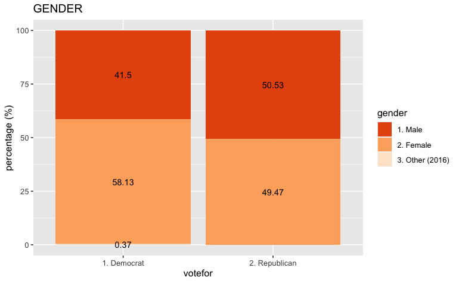

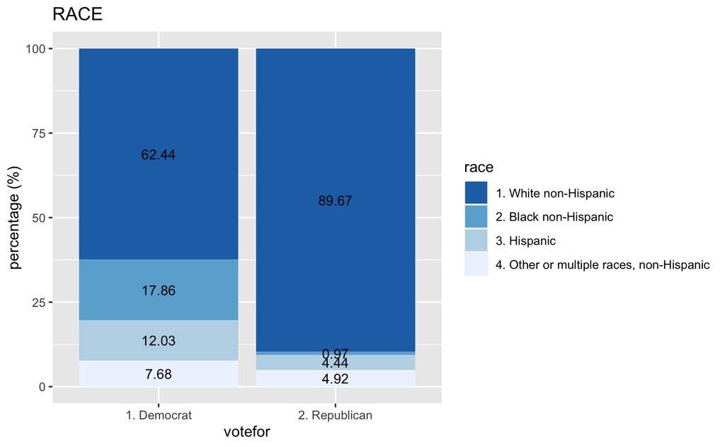

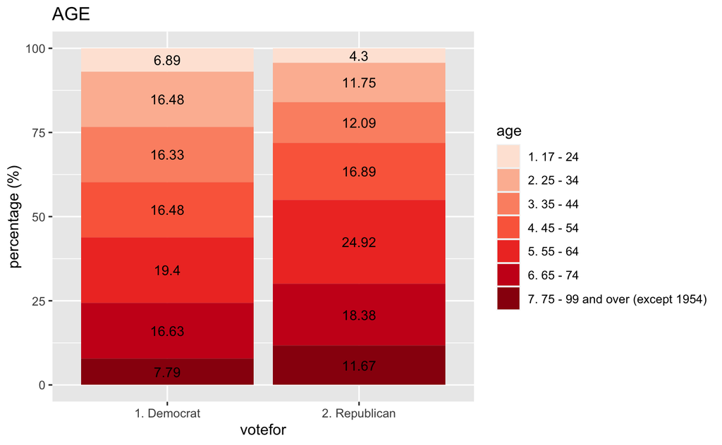

| votefor | age | cumulative |
| --- | --- | --- |
| 1. Democrat | 1. 17 - 24 | 6.89 |
| 1. Democrat | 2. 25 - 34 | 23.37 |
| 1. Democrat | 3. 35 - 44 | 39.70 |
| 1. Democrat | 4. 45 - 54 | 56.18 |
| 1. Democrat | 5. 55 - 64 | 75.58 |
| 1. Democrat | 6. 65 - 74 | 92.21 |
| 1. Democrat | 7. 75 - 99 and over (except 1954) | 100.00 |
| 2. Republican | 1. 17 - 24 | 4.30 |
| 2. Republican | 2. 25 - 34 | 16.05 |
| 2. Republican | 3. 35 - 44 | 28.14 |

[output cut: 4 more lines]

It’s seems like people’s level of education and their class also affect their choice of voting. I will also group people by education level and class to see the different constitutions between Republican voters and Democrat voters.

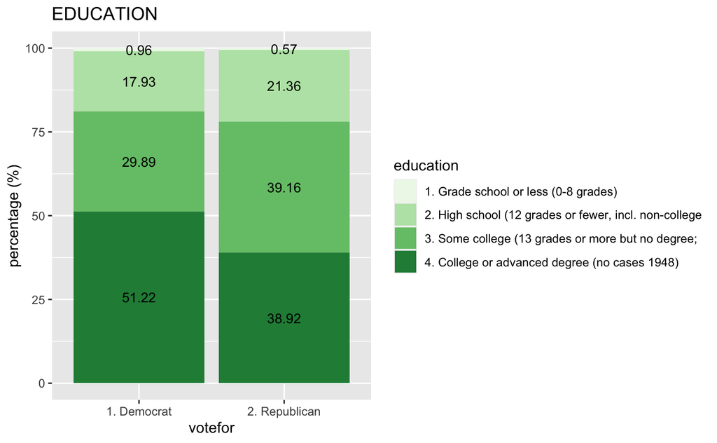

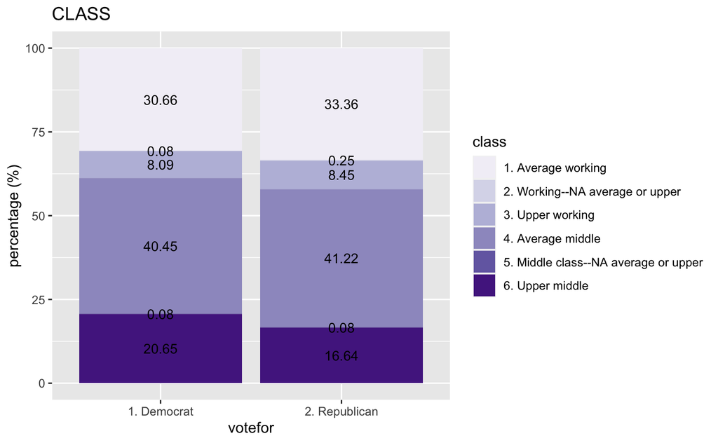

## (iii) How did 2016 voters and nonvoters compare?

As in the section 1 discussed, there are 78% people chose to vote for the president in 2016, while 21% chose not to vote. In this section, by analyzing and visualizing the data, we want to find the answer to the following question: How did 2016 voters and nonvoters compare in terms of their interests in politics and the election?

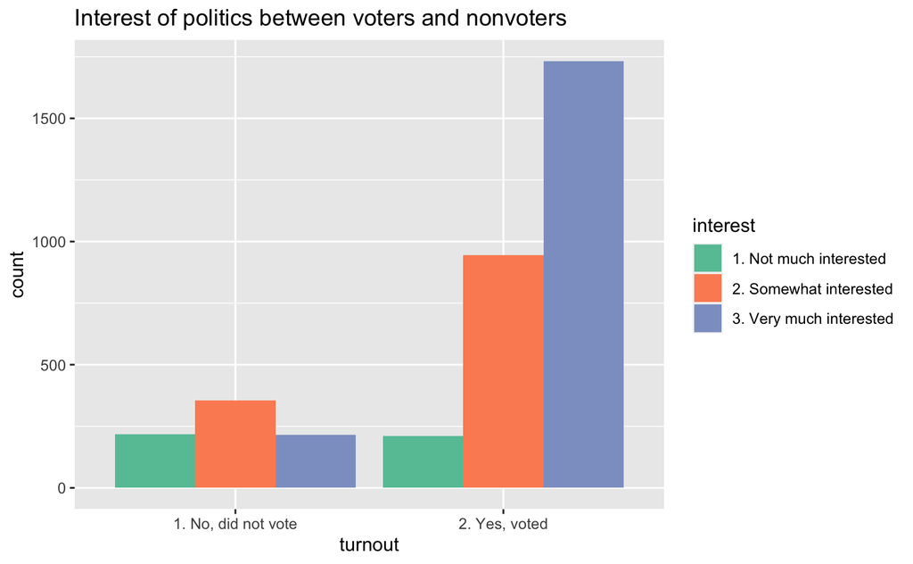

I picked the question in the survey about how much have people been interested in the political campaigns: not much interested, somewhat interested, and very much interested. By looking at the plot, unsurprisingly, a large amount of people who voted in the election were very much interested in the political campaigns, while there were also some people who were not much interested in politics also voted.

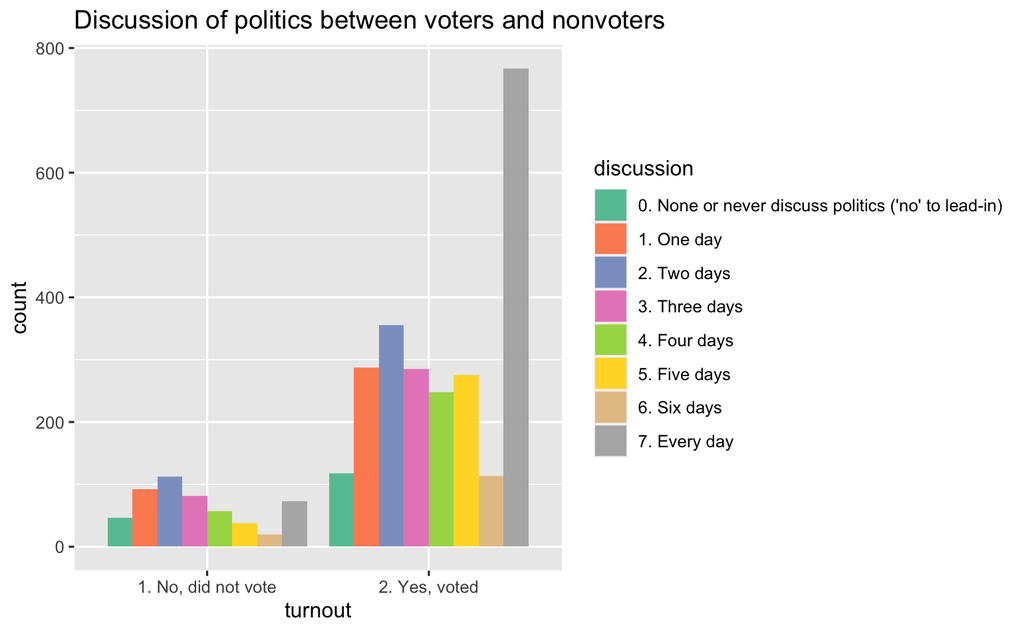

The survey also asked about how many days in the past week did people talk about politics with family or friends. For people who voted in the 2016 election, they often talked about politics more than 5 days in a week, especially a large number of people talked about politics with their family and friends everyday. In the contrast, many people who did not vote in the election only discussed about politics less than 2 days a week. This result can validate my initial guess that people who are more engaged with political conversations are more likely to vote.

| turnout | donation | n |
| --- | --- | --- |
| 1. No, did not vote | 1. Yes | 9 |
| 1. No, did not vote | 2. No | 777 |
| 2. Yes, voted | 1. Yes | 132 |
| 2. Yes, voted | 2. No | 2729 |

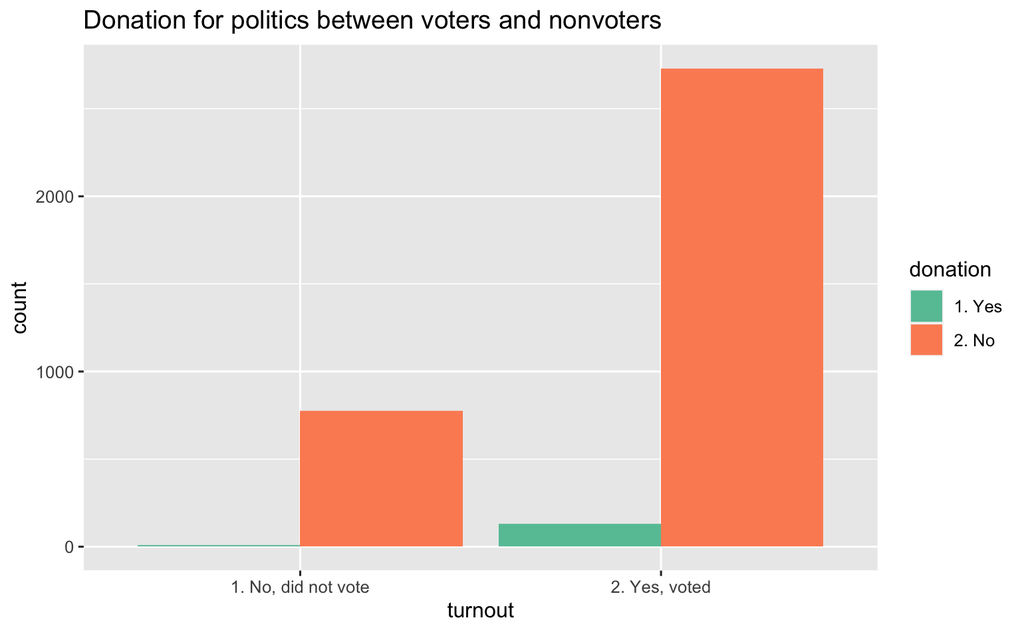

I also examined whether people have donated money to a particular individual candidate, a political party organization, people supporting a ballot proposition, or to a particular issue or interest group. For both groups, most of the people did not donate money to any of the groups mentioned above. Interestingly, there are 9 people who did not vote for the president used to give money to support campaigns.